# Mobile phone price classifiaction

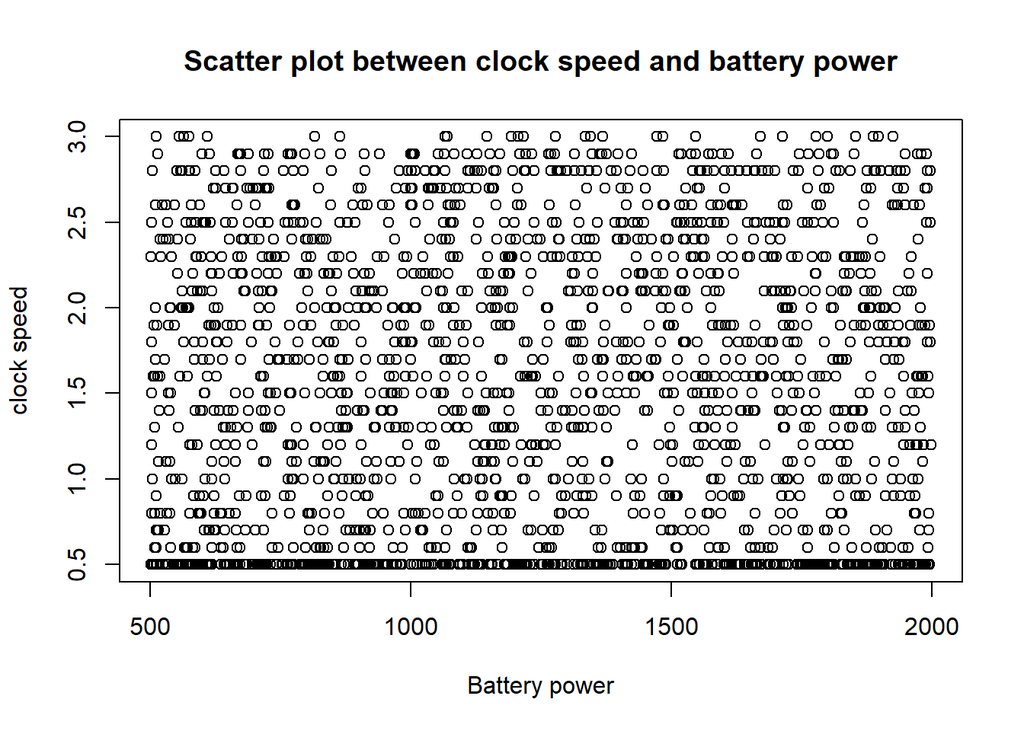

```r
#Plotting a scatter plot between battery power and clock speed
plot(phone_df$battery_power, phone_df$clock_speed, xlab="Battery power", ylab="clock speed", main = "Scatter plot between clock speed and battery power")
```

There is no correlation battery power and clock speed.

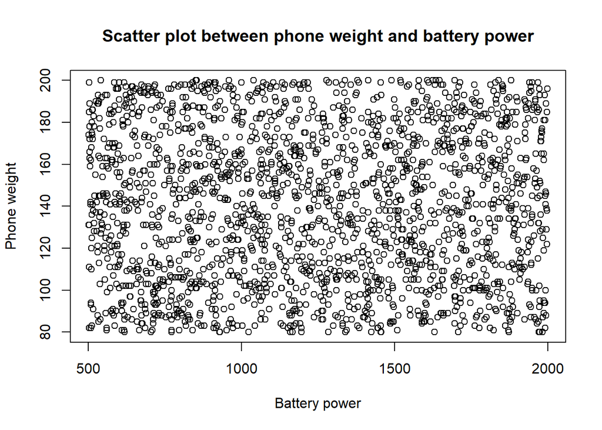

```r
# Plotting scatter plot of phone weight and battery power
plot(num_df$battery_power, num_df$mobile_wt, xlab="Battery power", ylab="Phone weight", main = "Scatter plot between phone weight and battery power")
```

Battery power and phone weight have no correlation

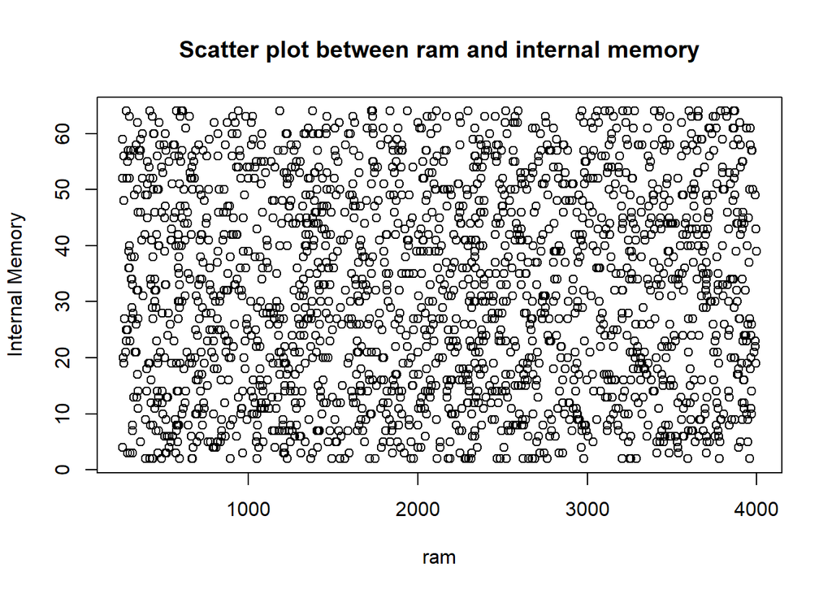

```r
# Plotting scatter plot of RAM and internal memory
plot(num_df$ram, num_df$int_memory, xlab="ram", ylab="Internal Memory", main = "Scatter plot between ram and internal memory")
```

There is no correlation between ram and internal memory

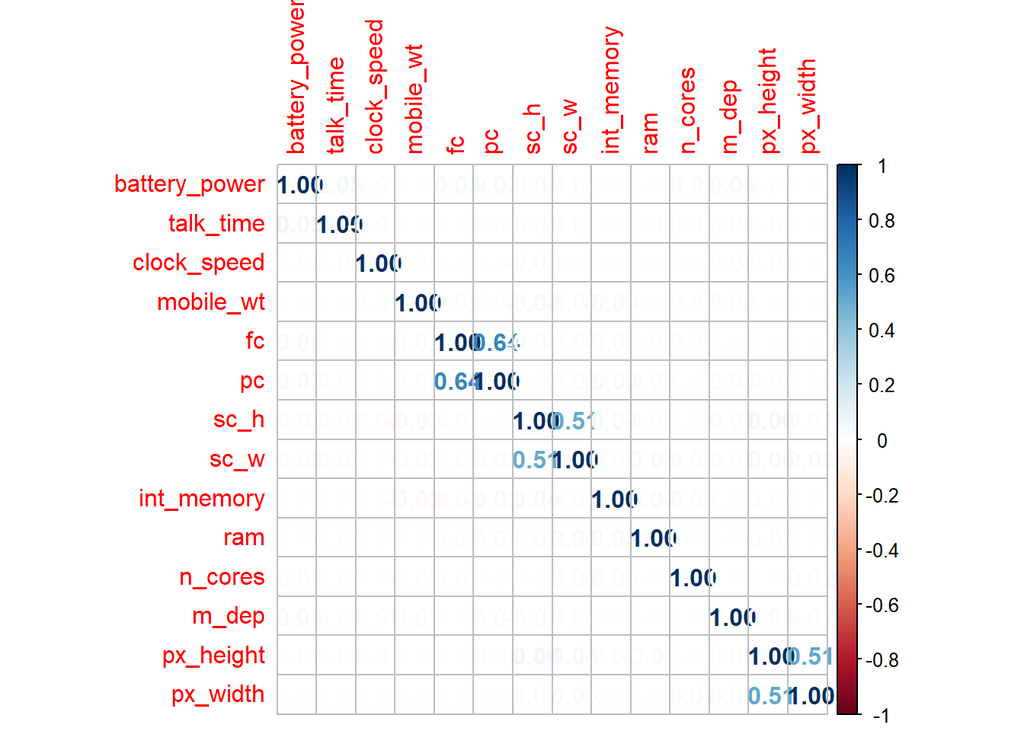

```r
#Finding the correlation of the numerical columns
library("dplyr")
library(corrplot)
#Assigning m to the correlation
# correlation matrix
M<-cor(num_df)

corrplot(M, method="number", order = "hclust")
```

* There is a high positive correlation front camera megapixels and primary camera megapixels * there is a moderately positive correlation between phone height and phone width

## FEATURE ENGINEERING

### Label encoding columns

```r
# Import the library for label encoding

library(superml)
# Introduce the label encoder object
label <- LabelEncoder$new()

#Label encoding the columns
phone_df$price_range <-label$fit_transform(phone_df$price_range)
phone_df$blue <-label$fit_transform(phone_df$blue)
phone_df$dual_sim <-label$fit_transform(phone_df$dual_sim)
phone_df$four_g <-label$fit_transform(phone_df$four_g)
phone_df$three_g <-label$fit_transform(phone_df$three_g)
phone_df$touch_screen <-label$fit_transform(phone_df$touch_screen)
phone_df$wifi <-label$fit_transform(phone_df$wifi)

#Previewing the head
head(phone_df)
```

```
##   battery_power blue clock_speed dual_sim fc four_g int_memory m_dep mobile_wt
## 1           842    0         2.2        0  1      0          7   0.6       188
## 2          1021    1         0.5        1  0      1         53   0.7       136
## 3           563    1         0.5        1  2      1         41   0.9       145
## 4           615    1         2.5        0  0      0         10   0.8       131
## 5          1821    1         1.2        0 13      1         44   0.6       141
## 6          1859    0         0.5        1  3      0         22   0.7       164
##   n_cores pc px_height px_width  ram sc_h sc_w talk_time three_g touch_screen
## 1       2  2        20      756 2549    9    7        19       0            0
## 2       3  6       905     1988 2631   17    3         7       1            1
## 3       5  6      1263     1716 2603   11    2         9       1            1
## 4       6  9      1216     1786 2769   16    8        11       1            0
## 5       2 14      1208     1212 1411    8    2        15       1            1
## 6       1  7      1004     1654 1067   17    1        10       1            0
##   wifi price_range
## 1    1           1
## 2    0           2
## 3    0           2
## 4    0           2
## 5    0           1
## 6    0           1
```

## FEATURE SELECTION

### Random Forest feature Selection

```r
#install.packages('Boruta')
library(Boruta)
```

```r
boruta_output <- Boruta(price_range~ ., data=phone_df, doTrace=0)
names(boruta_output)
```

```
##  [1] "finalDecision" "ImpHistory"    "pValue"        "maxRuns"
##  [5] "light"         "mcAdj"         "timeTaken"     "roughfixed"
##  [9] "call"          "impSource"
```

```r
# Get significant variables including tentatives
boruta_signif <- getSelectedAttributes(boruta_output, withTentative = TRUE)
print(boruta_signif)
```

```
## [1] "battery_power" "mobile_wt"     "px_height"     "px_width"
## [5] "ram"           "sc_h"          "sc_w"
```

### LINEAR DISCRIMINANT ANALYSIS

```r
# Importing the necessary libraries

library(MASS)
library(tidyverse)
library(caret)
theme_set(theme_classic())


# Split the data into training (80%) and test set (20%)
set.seed(123)
training_data <- phone_df$price_range %>%
            createDataPartition(p = 0.8, list = FALSE)
train_data <- phone_df[training_data, ]
test_data <- phone_df[-training_data, ]

head(train_data)
```

```
##    battery_power blue clock_speed dual_sim fc four_g int_memory m_dep mobile_wt
## 2           1021    1         0.5        1  0      1         53   0.7       136
## 3            563    1         0.5        1  2      1         41   0.9       145
## 4            615    1         2.5        0  0      0         10   0.8       131
## 5           1821    1         1.2        0 13      1         44   0.6       141
## 9           1445    1         0.5        0  0      0         53   0.7       174
## 10           509    1         0.6        1  2      1          9   0.1        93
##    n_cores pc px_height px_width  ram sc_h sc_w talk_time three_g touch_screen
## 2        3  6       905     1988 2631   17    3         7       1            1
## 3        5  6      1263     1716 2603   11    2         9       1            1
## 4        6  9      1216     1786 2769   16    8        11       1            0
## 5        2 14      1208     1212 1411    8    2        15       1            1
## 9        7 14       386      836 1099   17    1        20       1            0
## 10       5 15      1137     1224  513   19   10        12       1            0
##    wifi price_range
## 2     0           2
## 3     0           2
## 4     0           2
## 5     0           1
## 9     0           0
## 10    0           0
```

```r
head(test_data)
```

```
##    battery_power blue clock_speed dual_sim fc four_g int_memory m_dep mobile_wt
## 1            842    0         2.2        0  1      0          7   0.6       188
## 6           1859    0         0.5        1  3      0         22   0.7       164
## 7           1821    0         1.7        0  4      1         10   0.8       139
## 8           1954    0         0.5        1  0      0         24   0.8       187
## 11           769    1         2.9        1  0      0          9   0.1       182
## 21           772    0         1.1        1 12      0         39   0.8        81
##    n_cores pc px_height px_width  ram sc_h sc_w talk_time three_g touch_screen
## 1        2  2        20      756 2549    9    7        19       0            0
## 6        1  7      1004     1654 1067   17    1        10       1            0
## 7        8 10       381     1018 3220   13    8        18       1            0
## 8        4  0       512     1149  700   16    3         5       1            1
## 11       5  1       248      874 3946    5    2         7       0            0
## 21       7 14      1314     1854 2819   17   15         3       1            1
##    wifi price_range
## 1     1           1
## 6     0           1
## 7     1           3
## 8     1           0
## 11    0           3
## 21    0           3
```

```r
#Scaling the data
prep <- train_data %>%
  preProcess(method = c("center", "scale"))

# Transform the data using the estimated parameters
train_transform <- prep %>% predict(train_data)
test_transform <- prep %>% predict(test_data)

# Fit the model
lda_model <- lda(price_range~., data = train_transform)

# Make predictions
lda_pred <- lda_model %>% predict(test_transform)
```

```r
# Model accuracy
mean(lda_pred$class==test_transform$price_range)
```

```
## [1] 0.9325
```

```r
lda_model <- lda(price_range~., data = train_transform)
lda_model
```

```
## Call:
## lda(price_range ~ ., data = train_transform)
##
## Prior probabilities of groups:
##  -1.34122145822381 -0.447073819407936  0.447073819407936   1.34122145822381
##               0.25               0.25               0.25               0.25
##
## Group means:
##                    battery_power         blue clock_speed    dual_sim
## -1.34122145822381    -0.24329742  0.006248169  0.05229951 -0.03374538
## -0.447073819407936   -0.03587177 -0.013745971 -0.06991136 -0.01874744
## 0.447073819407936    -0.04619644 -0.033740110  0.02871496 -0.01874744
## 1.34122145822381      0.32536563  0.041237913 -0.01110312  0.07124025
##                              fc      four_g   int_memory       m_dep
## -1.34122145822381  -0.051684291 -0.01000701 -0.013187778 -0.03872435
## -0.447073819407936  0.047664402 -0.02501753 -0.002416609  0.08675120
## 0.447073819407936  -0.002297080 -0.07505259 -0.058343836 -0.03353226
## 1.34122145822381    0.006316969  0.11007713  0.073948223 -0.01449459
##                      mobile_wt     n_cores          pc   px_height     px_width
## -1.34122145822381   0.02012015  0.05627789 -0.05039894 -0.22422964 -0.235349956
## -0.447073819407936  0.03856214 -0.05353263  0.04356869  0.03098607 -0.007323519
## 0.447073819407936   0.07509284  0.02772716 -0.05743616 -0.02887564 -0.040786725
## 1.34122145822381   -0.13377513 -0.03047242  0.06426641  0.22211920  0.283460200
##                           ram        sc_h         sc_w   talk_time      three_g
## -1.34122145822381  -1.2404994  0.03595946 -0.003152631 -0.07468700 -0.023665385
## -0.447073819407936 -0.4095125 -0.03298760 -0.037544973  0.08393617  0.005916346
## 0.447073819407936   0.4256313 -0.04546940  0.021495214  0.02011693  0.005916346
## 1.34122145822381    1.2243806  0.04249754  0.019202391 -0.02936610  0.011832692
##                    touch_screen         wifi
## -1.34122145822381    0.03249238 -0.036240964
## -0.447073819407936   0.05248769  0.003749065
## 0.447073819407936   -0.05248769  0.008747819
## 1.34122145822381    -0.03249238  0.023744080
##
## Coefficients of linear discriminants:
##                         LD1         LD2          LD3
## battery_power  0.7087374062  0.47214521 -0.022620536
## blue           0.0029833906  0.12423080 -0.077986128
## clock_speed   -0.0277795558 -0.12161875 -0.341989231
## dual_sim      -0.0322164290  0.15552340 -0.030500966
## fc             0.0199631360 -0.19553915  0.262651861
## four_g         0.0186127661  0.45863760 -0.304674558
## int_memory     0.0497039673  0.24305686 -0.040256641
## m_dep         -0.0022209964  0.10049852  0.389470922
## mobile_wt     -0.1029326251 -0.32348689  0.202014571
## n_cores       -0.0069609069 -0.11644299 -0.301347681
## pc             0.0159848656  0.38542895 -0.013988687
## px_height      0.4090258307  0.15445946  0.350864308
## px_width       0.4019539963  0.33341753  0.002004295
## ram            3.3877770306 -0.23438053 -0.042327652
## sc_h           0.0346788881  0.26284437 -0.218419825
## sc_w          -0.0206605940 -0.18338459 -0.001579534
## talk_time     -0.0068129671 -0.07179924  0.489187472
## three_g        0.0232003118 -0.27680535  0.258357153
## touch_screen  -0.0005617955  0.14447156  0.143293117
## wifi          -0.0289482079 -0.01290631  0.069169441
##
## Proportion of trace:
##    LD1    LD2    LD3
## 0.9964 0.0024 0.0012
```

```r
#Selecting the important features

imp_features <- phone_df[c('battery_power', 'px_height', 'px_width', 'sc_h', 'sc_w', 'ram')]
head(imp_features)
```

```
##   battery_power px_height px_width sc_h sc_w  ram
## 1           842        20      756    9    7 2549
## 2          1021       905     1988   17    3 2631
## 3           563      1263     1716   11    2 2603
## 4           615      1216     1786   16    8 2769
## 5          1821      1208     1212    8    2 1411
## 6          1859      1004     1654   17    1 1067
```

```r
#Combining the important features with the target columns
df <- do.call(cbind,list(imp_features, phone_df['price_range']))
head(df)
```

```
##   battery_power px_height px_width sc_h sc_w  ram price_range
## 1           842        20      756    9    7 2549           1
## 2          1021       905     1988   17    3 2631           2
## 3           563      1263     1716   11    2 2603           2
## 4           615      1216     1786   16    8 2769           2
## 5          1821      1208     1212    8    2 1411           1
## 6          1859      1004     1654   17    1 1067           1
```

## SUPERVISED LEARNING

### 1) LOGISTIC REGRESSION

```r
# Loading package
library(caTools)
library(ROCR)
library(nnet)


# Splitting dataset into 80% train with 20% test

split <- sample.split(df, SplitRatio = 0.8)
split
```

```
## [1]  TRUE FALSE  TRUE  TRUE  TRUE FALSE  TRUE
```

```r
#Creating a test and train set.
train_log <- subset(df, split == "TRUE")
test_log <- subset(df, split == "FALSE")

#Previewing the top 6 entries of both train and test
head(train_log)
```

```
##   battery_power px_height px_width sc_h sc_w  ram price_range
## 1           842        20      756    9    7 2549           1
## 3           563      1263     1716   11    2 2603           2
## 4           615      1216     1786   16    8 2769           2
## 5          1821      1208     1212    8    2 1411           1
## 7          1821       381     1018   13    8 3220           3
## 8          1954       512     1149   16    3  700           0
```

```r
head(test_log)
```

```
##    battery_power px_height px_width sc_h sc_w  ram price_range
## 2           1021       905     1988   17    3 2631           2
## 6           1859      1004     1654   17    1 1067           1
## 9           1445       386      836   17    1 1099           0
## 13          1815       607      748   18    0 1482           1
## 16           775       862     1864   17   15  568           0
## 20           682       902     1064   11    1 2337           1
```

```r
# Fit the multinomial class to the dataset
model <- nnet::multinom(price_range ~., data = train_log)
# Summarize the model
summary(model)
```

```
## Call:
## nnet::multinom(formula = price_range ~ ., data = train_log)
##
## Coefficients:
##   (Intercept) battery_power  px_height   px_width        sc_h        sc_w
## 1   -106.4547    0.02413941 0.01593140 0.01396352 -0.03698317  0.01906823
## 2   -231.7930    0.04581005 0.02768021 0.02734275 -0.01106152 -0.07364277
## 3   -360.0466    0.06387828 0.03698117 0.03789138  0.30258047 -0.13615634
##          ram
## 1 0.04156511
## 2 0.07672319
## 3 0.10415300
##
## Std. Errors:
##    (Intercept) battery_power   px_height    px_width      sc_h      sc_w
## 1 0.0004320367  0.0007042805 0.001006271 0.000857012 0.1000340 0.1034704
## 2 0.0003341965  0.0009208844 0.001282231 0.001153954 0.1324942 0.1345349
## 3 0.0004214094  0.0010489839 0.001452538 0.001334677 0.1539323 0.1523534
##            ram
## 1 0.0007776751
## 2 0.0008959756
## 3 0.0009450634
##
## Residual Deviance: 219.4531
## AIC: 261.4531
```

```r
# Make predictions
predicted.classes <- model %>% predict(test_log)
head(predicted.classes)
```

```
## [1] 2 1 0 1 0 1
## Levels: 0 1 2 3
```

```r
# Model accuracy
mean(predicted.classes == test_log$price_range)
```

```
## [1] 0.9562172
```

```r
#Finding the accuracy of the model.
mean(predicted.classes == test_log$price_range)
```

```
## [1] 0.9562172
```

```r
# Making the Confusion Matrix
log_cm = table(test_log$`price_range`, predicted.classes)
confusionMatrix(log_cm)
```

```
## Confusion Matrix and Statistics
##
##    predicted.classes
##       0   1   2   3
##   0 154   6   0   0
##   1   3 147   3   0
##   2   0   6 120   3
##   3   0   0   4 125
##
## Overall Statistics
##
##                Accuracy : 0.9562
##                  95% CI : (0.936, 0.9715)
##     No Information Rate : 0.2785
##     P-Value [Acc > NIR] : < 2.2e-16
##
##                   Kappa : 0.9414
##
##  Mcnemar's Test P-Value : NA
##
## Statistics by Class:
##
##                      Class: 0 Class: 1 Class: 2 Class: 3
## Sensitivity            0.9809   0.9245   0.9449   0.9766
## Specificity            0.9855   0.9854   0.9797   0.9910
## Pos Pred Value         0.9625   0.9608   0.9302   0.9690
## Neg Pred Value         0.9927   0.9713   0.9842   0.9932
## Prevalence             0.2750   0.2785   0.2224   0.2242
## Detection Rate         0.2697   0.2574   0.2102   0.2189
## Detection Prevalence   0.2802   0.2680   0.2259   0.2259
## Balanced Accuracy      0.9832   0.9550   0.9623   0.9838
```

### 2) K-NEAREST NEIGHBOUR

```r
# Loading package
library(e1071)
library(class)
library(caTools)
library(ROCR)

# Splitting data into train
# and test data
split <- sample.split(df, SplitRatio = 0.7)
train_knn <- subset(df, split == "TRUE")
test_knn <- subset(df, split == "FALSE")

# Feature Scaling
train_scale <- scale(train_knn[,c(1:6)])
test_scale <- scale(test_knn[,c(1:6)])

# Fitting KNN Model
# to training dataset
classifier_knn <- knn(train = train_knn,
                      test = test_knn,
                      cl = train_knn$price_range,
                      k = 44)
```

Using a random number of k at 44 we check its accuracy.

```r
# Making the Confusion Matrix
cm = table(test_knn$`price_range`, classifier_knn)
confusionMatrix(cm)
```

```
## Confusion Matrix and Statistics
##
##    classifier_knn
##       0   1   2   3
##   0 208   5   0   0
##   1  12 196  10   0
##   2   0  29 179  10
##   3   0   0  13 195
##
## Overall Statistics
##
##                Accuracy : 0.9078
##                  95% CI : (0.8864, 0.9263)
##     No Information Rate : 0.2684
##     P-Value [Acc > NIR] : < 2.2e-16
##
##                   Kappa : 0.8771
##
##  Mcnemar's Test P-Value : NA
##
## Statistics by Class:
##
##                      Class: 0 Class: 1 Class: 2 Class: 3
## Sensitivity            0.9455   0.8522   0.8861   0.9512
## Specificity            0.9922   0.9649   0.9405   0.9801
## Pos Pred Value         0.9765   0.8991   0.8211   0.9375
## Neg Pred Value         0.9814   0.9468   0.9640   0.9846
## Prevalence             0.2567   0.2684   0.2357   0.2392
## Detection Rate         0.2427   0.2287   0.2089   0.2275
## Detection Prevalence   0.2485   0.2544   0.2544   0.2427
## Balanced Accuracy      0.9688   0.9085   0.9133   0.9656
```

#### Finding optimum K

```r
library(ISLR)
library(caret)
# Split the data:
indxTrain <- createDataPartition(y = df$price_range,p = 0.75,list = FALSE)
training <- df[indxTrain,]
testing <- df[-indxTrain,]
# Run k-NN:
set.seed(400)
ctrl <- trainControl(method="repeatedcv",repeats = 3)
knnFit <- train(price_range ~ ., data = training, method = "knn", trControl = ctrl, preProcess = c("center","scale"),tuneLength = 20)
knnFit
```

```
## k-Nearest Neighbors
##
## 1500 samples
##    6 predictor
##
## Pre-processing: centered (6), scaled (6)
## Resampling: Cross-Validated (10 fold, repeated 3 times)
## Summary of sample sizes: 1351, 1351, 1350, 1348, 1349, 1350, ...
## Resampling results across tuning parameters:
##
##   k   RMSE       Rsquared   MAE
##    5  0.3641899  0.8964198  0.2699745
##    7  0.3488467  0.9071953  0.2677170
##    9  0.3425185  0.9126109  0.2680995
##   11  0.3380027  0.9173989  0.2691986
##   13  0.3372291  0.9201243  0.2713491
##   15  0.3361575  0.9226530  0.2729432
##   17  0.3381444  0.9232985  0.2768243
##   19  0.3413180  0.9233810  0.2807974
##   21  0.3443734  0.9232652  0.2838767
##   23  0.3470342  0.9236577  0.2867396
##   25  0.3498840  0.9239154  0.2898827
##   27  0.3532034  0.9239536  0.2924360
##   29  0.3572841  0.9233647  0.2969372
##   31  0.3608065  0.9233138  0.3007642
##   33  0.3635199  0.9236366  0.3034647
##   35  0.3661002  0.9238794  0.3063208
##   37  0.3683571  0.9243930  0.3089152
##   39  0.3714199  0.9243892  0.3113372
##   41  0.3742347  0.9242688  0.3141297
##   43  0.3770451  0.9241957  0.3164917
##
## RMSE was used to select the optimal model using the smallest value.
## The final value used for the model was k = 15.
```

Doing tuning to find the optimum number of neighbour to be 15.

#### using optimum k at 15

```r
# Fitting KNN Model
# to training dataset
classifier_knn2 <- knn(train = train_knn,
                      test = test_knn,
                      cl = train_knn$price_range,
                      k = 15)
#classifier_knn2
```

```r
# Making the Confusion Matrix
cm2 = table(test_knn$`price_range`, classifier_knn2)
confusionMatrix(cm2)
```

```
## Confusion Matrix and Statistics
##
##    classifier_knn2
##       0   1   2   3
##   0 208   5   0   0
##   1  13 195  10   0
##   2   0  26 184   8
##   3   0   0  12 196
##
## Overall Statistics
##
##                Accuracy : 0.9137
##                  95% CI : (0.8928, 0.9316)
##     No Information Rate : 0.2637
##     P-Value [Acc > NIR] : < 2.2e-16
##
##                   Kappa : 0.8849
##
##  Mcnemar's Test P-Value : NA
##
## Statistics by Class:
##
##                      Class: 0 Class: 1 Class: 2 Class: 3
## Sensitivity            0.9412   0.8628   0.8932   0.9608
## Specificity            0.9921   0.9635   0.9478   0.9816
## Pos Pred Value         0.9765   0.8945   0.8440   0.9423
## Neg Pred Value         0.9798   0.9515   0.9656   0.9877
## Prevalence             0.2579   0.2637   0.2404   0.2380
## Detection Rate         0.2427   0.2275   0.2147   0.2287
## Detection Prevalence   0.2485   0.2544   0.2544   0.2427
## Balanced Accuracy      0.9667   0.9132   0.9205   0.9712
```

From the tuned number of neighbours we find a slightly increased accuracy of 91.37.

### 3) Support Vector Machine

```r
# Splitting the dataset into the Training set and Test set
library(caTools)

set.seed(123)
split = sample.split(df$price_range, SplitRatio = 0.75)

train_set = subset(df, split == TRUE)
test_set = subset(df, split == FALSE)

head(train_set)
```

```
##   battery_power px_height px_width sc_h sc_w  ram price_range
## 1           842        20      756    9    7 2549           1
## 2          1021       905     1988   17    3 2631           2
## 3           563      1263     1716   11    2 2603           2
## 4           615      1216     1786   16    8 2769           2
## 6          1859      1004     1654   17    1 1067           1
## 7          1821       381     1018   13    8 3220           3
```

```r
head(test_set)
```

```
##    battery_power px_height px_width sc_h sc_w  ram price_range
## 5           1821      1208     1212    8    2 1411           1
## 8           1954       512     1149   16    3  700           0
## 9           1445       386      836   17    1 1099           0
## 13          1815       607      748   18    0 1482           1
## 17           838       984     1850   10    9 3554           3
## 18           595       441      810   10    2 3752           3
```

```r
# Feature Scaling the numerical columns
train_set[-7] <- scale(train_set[-7])
test_set[-7] <- scale(test_set[-7])

# Previewing the scaled dataset
train_set
```

[output not shown]

[output cut: 2987 more lines]

```r
test_set
```

[output not shown]

[output cut: 987 more lines]

```r
# Fitting SVM to the Training set
library(e1071)

svm_classifier = svm(formula = price_range ~ .,
                 data = train_set,
                 type = 'C-classification',
                 kernel = 'linear')
```

```r
# Predicting the Test set results
y_pred = predict(svm_classifier, newdata = test_set[-7])
#y_pred
```

```r
# Making the Confusion Matrix
cm_svm = table(test_set[, 7], y_pred)
confusionMatrix(cm_svm)
```

```
## Confusion Matrix and Statistics
##
##    y_pred
##       0   1   2   3
##   0 123   2   0   0
##   1   2 121   2   0
##   2   0   3 117   5
##   3   0   0   6 119
##
## Overall Statistics
##
##                Accuracy : 0.96
##                  95% CI : (0.9389, 0.9754)
##     No Information Rate : 0.252
##     P-Value [Acc > NIR] : < 2.2e-16
##
##                   Kappa : 0.9467
##
##  Mcnemar's Test P-Value : NA
##
## Statistics by Class:
##
##                      Class: 0 Class: 1 Class: 2 Class: 3
## Sensitivity            0.9840   0.9603   0.9360   0.9597
## Specificity            0.9947   0.9893   0.9787   0.9840
## Pos Pred Value         0.9840   0.9680   0.9360   0.9520
## Neg Pred Value         0.9947   0.9867   0.9787   0.9867
## Prevalence             0.2500   0.2520   0.2500   0.2480
## Detection Rate         0.2460   0.2420   0.2340   0.2380
## Detection Prevalence   0.2500   0.2500   0.2500   0.2500
## Balanced Accuracy      0.9893   0.9748   0.9573   0.9719
```

By tuning the kernel type we find that:

## UNSUPERVISED LEARNING

```r
# Scaling continuous variables
new_df <- scale(num_df,scale = TRUE)
head(new_df)
```

```
##      battery_power clock_speed         fc int_memory     m_dep  mobile_wt
## [1,]    -0.9023716   0.8305717 -0.7623040 -1.3802983 0.3406543  1.3489115
## [2,]    -0.4950148  -1.2527509 -0.9926421  1.1547354 0.6873763 -0.1200294
## [3,]    -1.5373020  -1.2527509 -0.5319659  0.4934223 1.3808201  0.1342103
## [4,]    -1.4189637   1.1982169 -0.9926421 -1.2149700 1.0340982 -0.2612737
## [5,]     1.3255743  -0.3949122  2.0017534  0.6587506 0.3406543  0.0212149
## [6,]     1.4120523  -1.2527509 -0.3016278 -0.5536569 0.6873763  0.6709387
##         n_cores         pc  px_height    px_width        ram       sc_h
## [1,] -1.1016958 -1.3054236 -1.4085963 -1.14649730  0.3916055 -0.7847870
## [2,] -0.6646016 -0.6458273  0.5856315  1.70403851  0.4672002  1.1139870
## [3,]  0.2095866 -0.6458273  1.3923360  1.07469943  0.4413873 -0.3100935
## [4,]  0.6466808 -0.1511300  1.2864279  1.23666169  0.5944205  0.8766402
## [5,] -1.1016958  0.6733654  1.2684009 -0.09142885 -0.6575015 -1.0221338
## [6,] -1.5387899 -0.4809282  0.8087146  0.93124714 -0.9746306  1.1139870
##            sc_w    talk_time
## [1,]  0.2830320  1.462127655
## [2,] -0.6351578 -0.734083618
## [3,] -0.8647053 -0.368048406
## [4,]  0.5125795 -0.002013194
## [5,] -0.8647053  0.730057231
## [6,] -1.0942527 -0.185030800
```

```r
# removing price_range from categorical
cat_df <- cat_df[,-7]

#Merging the scaled and categorical dataset
new_mobile<- do.call(cbind, list(new_df, cat_df))
head(new_mobile)
```

```
##   battery_power clock_speed         fc int_memory     m_dep  mobile_wt
## 1    -0.9023716   0.8305717 -0.7623040 -1.3802983 0.3406543  1.3489115
## 2    -0.4950148  -1.2527509 -0.9926421  1.1547354 0.6873763 -0.1200294
## 3    -1.5373020  -1.2527509 -0.5319659  0.4934223 1.3808201  0.1342103
## 4    -1.4189637   1.1982169 -0.9926421 -1.2149700 1.0340982 -0.2612737
## 5     1.3255743  -0.3949122  2.0017534  0.6587506 0.3406543  0.0212149
## 6     1.4120523  -1.2527509 -0.3016278 -0.5536569 0.6873763  0.6709387
##      n_cores         pc  px_height    px_width        ram       sc_h       sc_w
## 1 -1.1016958 -1.3054236 -1.4085963 -1.14649730  0.3916055 -0.7847870  0.2830320
## 2 -0.6646016 -0.6458273  0.5856315  1.70403851  0.4672002  1.1139870 -0.6351578
## 3  0.2095866 -0.6458273  1.3923360  1.07469943  0.4413873 -0.3100935 -0.8647053
## 4  0.6466808 -0.1511300  1.2864279  1.23666169  0.5944205  0.8766402  0.5125795
## 5 -1.1016958  0.6733654  1.2684009 -0.09142885 -0.6575015 -1.0221338 -0.8647053
## 6 -1.5387899 -0.4809282  0.8087146  0.93124714 -0.9746306  1.1139870 -1.0942527
##      talk_time blue dual_sim four_g three_g touch_screen wifi
## 1  1.462127655    0        0      0       0            0    1
## 2 -0.734083618    1        1      1       1            1    0
## 3 -0.368048406    1        1      1       1            1    0
## 4 -0.002013194    1        0      0       1            0    0
## 5  0.730057231    1        0      1       1            1    0
## 6 -0.185030800    0        1      0       1            0    0
```

### T-SNE

```r
#Creating t-sne model
library(caret)
library(Rtsne)
phone_df$price_range<-as.factor(phone_df$price_range)
colors = rainbow(length(unique(phone_df$price_range)))
names(colors) = unique(phone_df$price_range)
tsne_df <- Rtsne(new_mobile, dims = 2, perplexity=50, verbose=TRUE, max_iter = 1000)
```

```
## Performing PCA
## Read the 2000 x 20 data matrix successfully!
## OpenMP is working. 1 threads.
## Using no_dims = 2, perplexity = 50.000000, and theta = 0.500000
## Computing input similarities...
## Building tree...
## Done in 1.40 seconds (sparsity = 0.099965)!
## Learning embedding...
## Iteration 50: error is 72.481109 (50 iterations in 0.52 seconds)
## Iteration 100: error is 72.481121 (50 iterations in 0.88 seconds)
## Iteration 150: error is 72.481130 (50 iterations in 1.29 seconds)
## Iteration 200: error is 72.481139 (50 iterations in 1.70 seconds)
## Iteration 250: error is 72.481133 (50 iterations in 1.76 seconds)
## Iteration 300: error is 3.555186 (50 iterations in 1.70 seconds)
## Iteration 350: error is 3.555179 (50 iterations in 0.85 seconds)
## Iteration 400: error is 2.503200 (50 iterations in 0.40 seconds)
## Iteration 450: error is 2.469471 (50 iterations in 0.36 seconds)
## Iteration 500: error is 2.442267 (50 iterations in 0.36 seconds)
## Iteration 550: error is 2.425966 (50 iterations in 0.35 seconds)
## Iteration 600: error is 2.413666 (50 iterations in 0.36 seconds)
## Iteration 650: error is 2.406061 (50 iterations in 0.35 seconds)
## Iteration 700: error is 2.400482 (50 iterations in 0.35 seconds)
## Iteration 750: error is 2.395026 (50 iterations in 0.35 seconds)
## Iteration 800: error is 2.391542 (50 iterations in 0.35 seconds)
## Iteration 850: error is 2.387535 (50 iterations in 0.35 seconds)
## Iteration 900: error is 2.384628 (50 iterations in 0.37 seconds)
## Iteration 950: error is 2.381807 (50 iterations in 0.38 seconds)
## Iteration 1000: error is 2.379428 (50 iterations in 0.35 seconds)
## Fitting performed in 13.39 seconds.
```

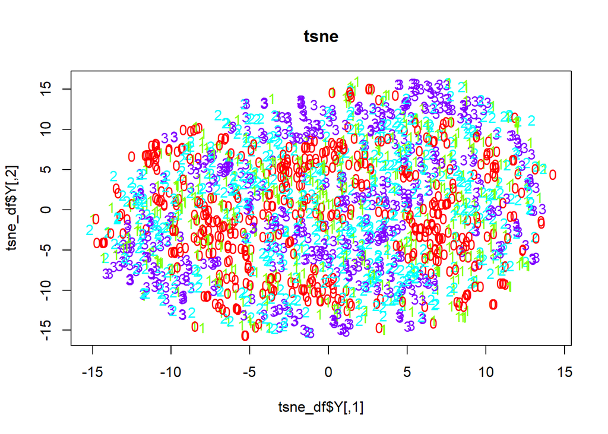

```r
#Plotting the t-sne
# Plotting our graph and closely examining the graph
plot(tsne_df$Y, t='n', main="tsne")
text(tsne_df$Y, labels=phone_df$price_range, col=colors[phone_df$price_range])
```

From the t_Sne plot above we note that there is no distinct clustering that can be noted from the clusters.

### K-mean clustering

#### Finding the optimum number of K to be used in K means.

```r
library(factoextra)
```

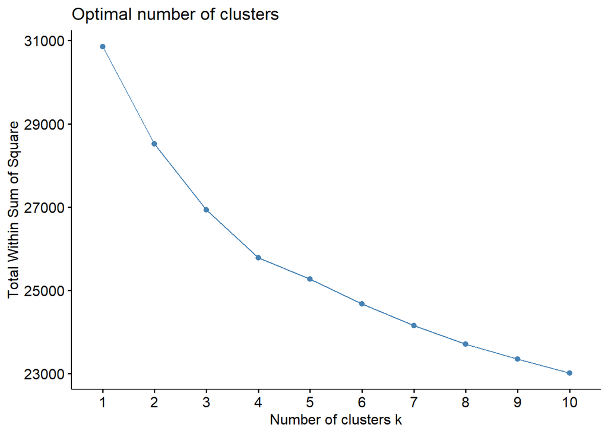

```r
library(tidyverse)
library(cluster)


#code for checking optimal with elbow method
fviz_nbclust(new_mobile, kmeans, method = "wss")
```

```r
# function to compute average silhouette for k clusters
avg_sil <- function(k) {
  km.res <- kmeans(new_mobile, centers = k, nstart = 25)
  ss <- silhouette(km.res$cluster, dist(new_mobile))
  mean(ss[, 3])
}
# Compute and plot wss for k = 2 to k = 15
k.values <- 2:15
# extract avg silhouette for 2-15 clusters
avg_sil_values <- map_dbl(k.values, avg_sil)
```

[output not shown]

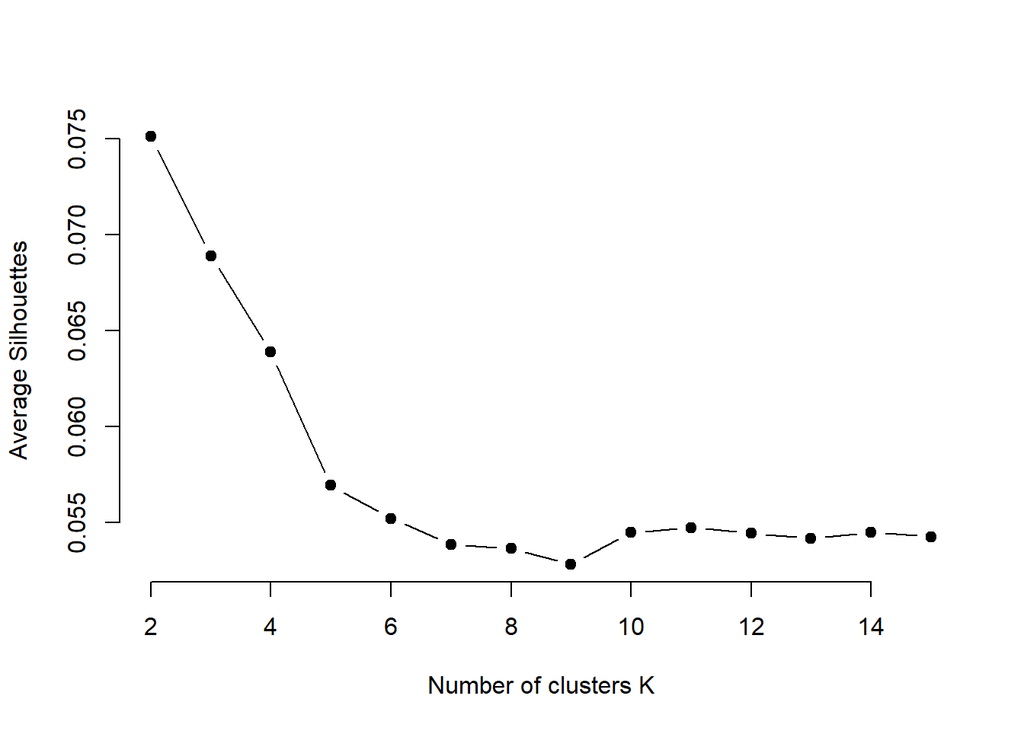

```r
plot(k.values, avg_sil_values,
       type = "b", pch = 19, frame = FALSE,
       xlab = "Number of clusters K",
       ylab = "Average Silhouettes")
```

From the elbow plot we note that the optimum number of k is 4.

```r
#Creating k mean cluster model assigning the result to the data used to create the tsne
#Using K to be 4 since we have classes.

df_kmeans <- kmeans(new_mobile,centers = 4)
```

```r
# Table of the clusters for k-means
table(df_kmeans$cluster)
```

```
##
##   1   2   3   4
## 458 466 604 472
```

```
##   cluster size ave.sil.width
## 1       1  458          0.06
## 2       2  466          0.07
## 3       3  604          0.07
## 4       4  472          0.05
```

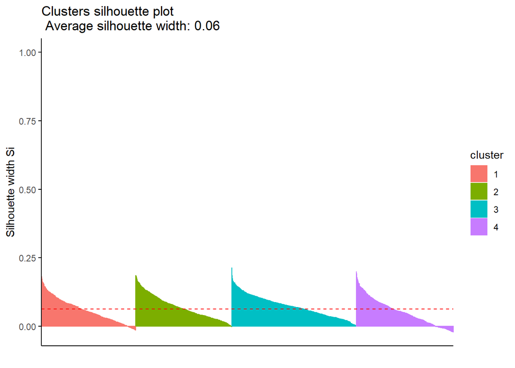

```r
# calculate silhouette
library(cluster)
sil <- silhouette(df_kmeans$cluster, dist(new_mobile))

# plot silhouette
library(factoextra)
fviz_silhouette(sil)
```

From the silhoute graph with value of 0.06 it means there is a small separation of the cluster.

## Conclusion

- High-cost mobile without for_g are bought more than those with four_g.
- Very high-cost mobile phones with four_g are bought more than those without.
- High-cost mobiles that are not touch screen are bought more than those that are touch screen
- Very high-cost mobiles that are touch screened are bought more than those that are not touch screened.
- High-cost mobile phones are bought equally without a dual sim.
- Very high-cost mobile phones with dual sims are bought more than those without.
- High-cost mobile phones with wifi have a small difference in how they are bought.
- Very high-cost mobile phones with wifi are bought more than those without.
- Very high-cost mobile phones with battery power are bought more than those without.
- There is no big difference in the clock speed in the different mobile price range
- Very high-cost mobile phones with battery power are bought more than those without.

## Recommendations

- In order to make more profits;
- The phone reseller should stock more phones of very high cost with four_g because they are bought more than the other phones.
- The phone reseller should stock more phones that are of very high cost and are touch screened are because they bought more than those that are not touch screened.
- The phone reseller should stock more phones that are of very high cost and with wifi are because they are bought more than those without. *The phone reseller should stock more phones that are of very high cost and with dual sim is because they bought more than those without.
- The phone reseller should stock more phones that are of low-cost mobiles that are touch screen because they are bought more than those that are not touch screened.

The most important features in determining the price range were; Battery_power- Total energy a battery can store in one time measured in mAh RAM- Random Acess Memory in gigabites Px_height - Pixel Resolution Height Px_width - Pixel Resolution Width Sc_h - Screen Height of mobile in cm Sc_w - Screen Width of mobile in cm

From the supervised model, the best model for predicting the mobile price class range is the Support Vector Machines model with an accuracy of 96% which was better than the other models used to make predictions.